# Amazon Employee Retention Analysis

### Exploratory Data Analysis

After data preprocessing, I conducted exploratory data analysis.

Distribution of the sentiment

```r
dim(culture_positive)
```

```
## [1] 5175    5
```

```r
dim(culture_negative)
```

```
## [1] 1552    5
```

We can see that the number of positive reviews is about **3.3 times** the number of negative ones. But both of the sentiments have sufficient data for analysis.

Let’s check the **word frequency per sentiment**:

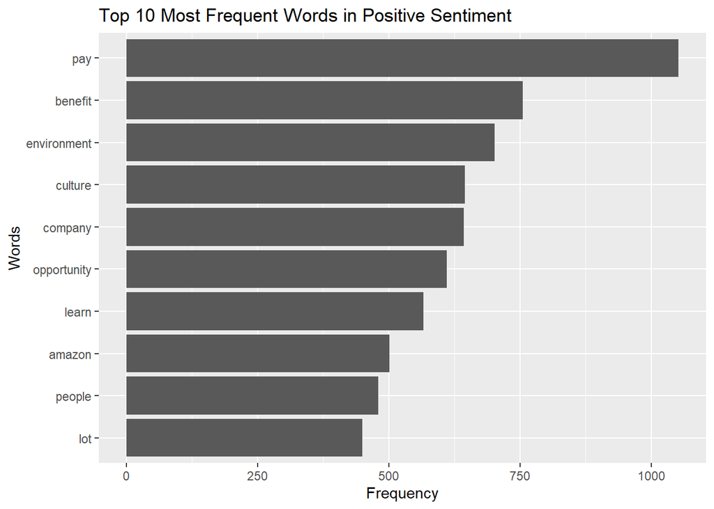

```r
## Culture Positive
# Unnest tokens to split the text into words
word_freq_cult_positive <- culture_positive %>%
  unnest_tokens(word, lemmatized_text) %>%
  count(word, sort = TRUE)

word_freq_cult_positive  %>%
  top_n(10) %>%
  ggplot(aes(x = reorder(word, n), y = n)) +
  geom_bar(stat = "identity") +
  coord_flip() +
  labs(title = "Top 10 Most Frequent Words in Positive Sentiment", x = "Words", y = "Frequency")
```

The graph shows that words like **pay, benefit, environment** and **culture** appear frequently in **positive** reviews.

Now let’s check the word frequency in **negative** reviews.

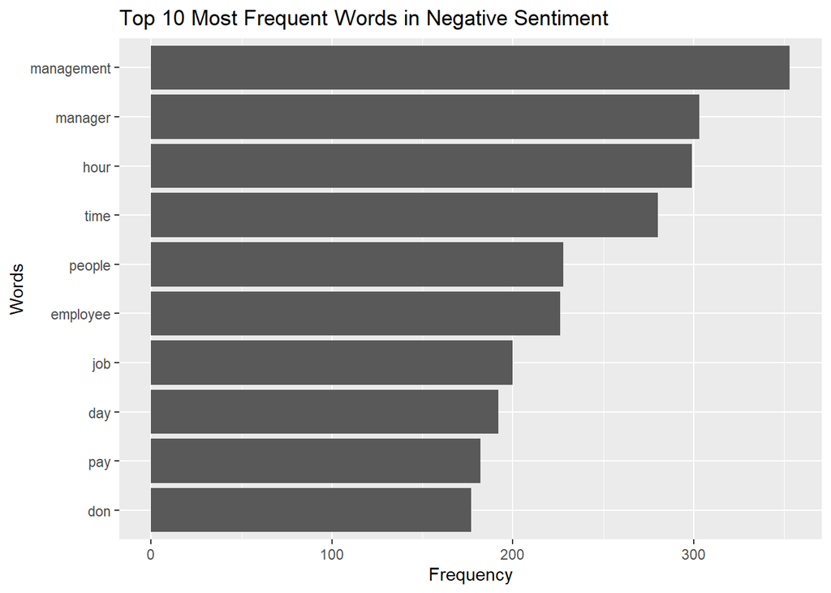

```r
## Culture Negative
# Unnest tokens to split the text into words
word_freq_cult_negative <- culture_negative %>%
  unnest_tokens(word, lemmatized_text) %>%
  count(word, sort = TRUE)

word_freq_cult_negative  %>%
  top_n(10) %>%
  ggplot(aes(x = reorder(word, n), y = n)) +
  geom_bar(stat = "identity") +
  coord_flip() +
  labs(title = "Top 10 Most Frequent Words in Negative Sentiment", x = "Words", y = "Frequency")
```

Based on the graph the common words in negative reviews are **management, manager, hour** and **time**.

Let’s use word cloud to have a good looking visualization.

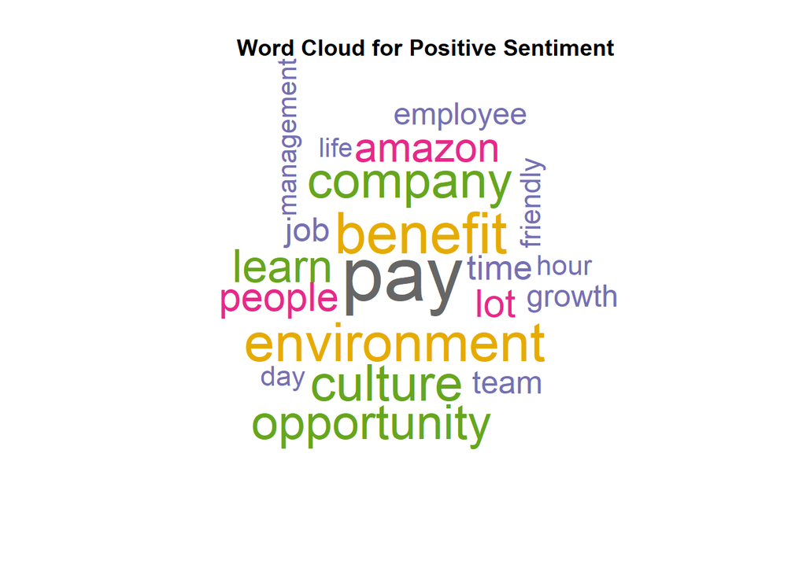

```r
# Positive Word Cloud
word_freq_cult_positive %>%
  with(wordcloud(words = word,
                 freq = n,
                 min.freq = 10,
                 max.words = 20,
                 random.order = FALSE,
                 colors = brewer.pal(8, "Dark2")))
title("Word Cloud for Positive Sentiment")
```

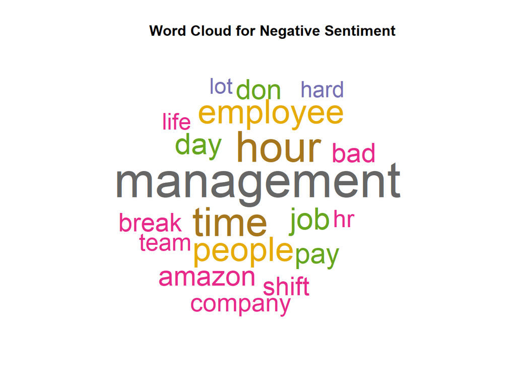

```r
# Negative Word Cloud
word_freq_cult_negative %>%
  with(wordcloud(words = word,
                 freq = n,
                 min.freq = 10,
                 max.words = 20,
                 random.order = FALSE,
                 colors = brewer.pal(8, "Dark2")))
title("Word Cloud for Negative Sentiment")
```

The results from 2 sentiments are different, but it does not give much of an insight. I will calculate **TF-IDF score** to extract more meaningful details.

### **Data Analysis**

I started off by label the **pros** as **Positive** and **cons** as **Negative**

```r
culture_positive <- culture_positive |>
  mutate(label = "Positive")

culture_negative <- culture_negative |>
  mutate(label = "Negative")

# 合併 culture_positive 和 culture_negative
culture_total <- bind_rows(culture_positive, culture_negative)
```

Then I perform tokenization for both of the sentiment and **calculate TF-IDF score**.

```r
## Culture Positive
# Tokenize the lemmatized text and count word frequencies by document
word_count <- culture_total %>%
  unnest_tokens(word, lemmatized_text) %>%
  count(label,word, sort = TRUE)

# Calculate TF-IDF
tf_idf <- word_count %>%
  bind_tf_idf(word, label, n)

# Preview the TF-IDF scores
head(tf_idf)
```

```
## # A tibble: 6 × 6
##   label    word            n     tf   idf tf_idf
##   <chr>    <chr>       <int>  <dbl> <dbl>  <dbl>
## 1 Positive pay          1052 0.0337     0      0
## 2 Positive benefit       756 0.0242     0      0
## 3 Positive environment   702 0.0225     0      0
## 4 Positive culture       645 0.0206     0      0
## 5 Positive company       643 0.0206     0      0
## 6 Positive opportunity   611 0.0195     0      0
```

I visualize the **top 20 words in both positive and negative sentiment**.

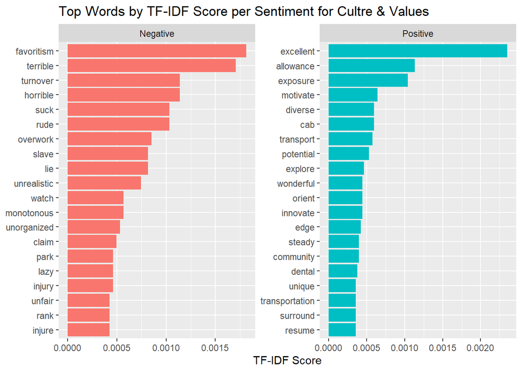

```r
# Get the top 20 words per sentiment based on TF-IDF scores
tf_idf_top_words <- tf_idf %>%
  group_by(label) %>%
  arrange(desc(tf_idf)) %>%
  slice_head(n = 20) %>%  # Select top 20 words
  ungroup()

# Reorder words within each sentiment for plotting
tf_idf_top_words <- tf_idf_top_words %>%
  mutate(word = reorder_within(word, tf_idf, label))

# Plot the top words per sentiment category
ggplot(tf_idf_top_words, aes(tf_idf, word, fill = label)) +
  geom_col(show.legend = FALSE) +
  facet_wrap(~ label, scales = "free") +
  scale_y_reordered() +
  labs(title = "Top Words by TF-IDF Score per Sentiment for Cultre & Values",
       x = "TF-IDF Score",
       y = NULL)
```

### **Results**

We can see that in the **negative** part, a number of employees feel there is a **lack of equity** and inclusiveness due to issues like **favoritism**. Additionally, some perceive the **workload as excessive** while the work is **unorganized** and **unattainable**, leading to frustration. Words like **rude**, **lie** and **unfair** suggest a **toxic work culture**.

On the other hand, in the **positive** part, Amazon does a great job in **creating an innovative environment** that promotes **diversity** in ideas and culture. Employees feel **motivated** and appreciate the **growth** opportunities that help them explore and develop their potential.

## **Conclusion & Suggestion**

In this project, we want to solve the problem and help Amazon **identify rooms for improvement in order to retain their employees**. To do that, we conducted **Linear Regression analysis** to identify that **Culture & Values** is the category that Amazon should prioritize in improving.

And within Culture & Values, we were able to extract keywords and found out that although **Amazon is an innovative company that supports employees’ growth**, but the environment is somewhat **toxic, unorganized and even lack of equity**.

Thus, I suggest that Amazon should **maintain the work environment to be innovative and diverse while supporting the employees to make progress**.

However, Amazon should definitely **improve their environment to boast fairness and inclusivity** by providing **DEI programs** such as **mentor** and **change of advancement practices**. Also, the company need to work on their **workload management** by **analyzing and optimizing their working processes**. As for the **toxic environment**, Amazon should consider providing a **leadership program or conflict solving training** to help build trust and respect within the organization.